# Distribuições discretas

ProbEst

fnaufel

28/10/2020 (modificado em 17/09/2021)

# 1 Uniforme discreta

## 1.1 Exemplo: um dado

- Cada resultado de $1$ a $6$ tem a mesma probabilidade de ocorrer.
- Variável aleatória $X$
- Suporte $\{ 1, 2,3 ,4 ,5 , 6 \}$
- Distribuição: $\text{Unif}(X \mid n=6)$:
  $$P(X = x) = \begin{cases}
  1/6 &\text{se } x \in \{1, 2, 3, 4, 5, 6\} \\
  0 &\text{senão}
  \end{cases}$$

## 1.2 No geral

- $\text{Unif}(X = x \mid n)$
- $n \in \mathbb{N}^+$
- Distribuição: $\text{Unif}(X \mid n)$:
  $$P(X = x) = \begin{cases}
  1/n &\text{se } x \in \{1, \ldots, n\} \\
  0 &\text{senão}
  \end{cases}$$
- Valor esperado:
  $$\begin{align*}
  E(X) &= \frac{1}{n} \cdot (1 + \cdots + n)\\
  &= \frac{1}{n} \cdot \frac{n(n+1)}{2}\\
  &= \frac{n+1}{2}
  \end{align*}$$
- Variância:
  $$\begin{align}
  \sigma^2(X) &= \sum \left[(x_i - \mu)^2 \cdot \frac1n \right]
  & \text{(definição de variância)}\\
  &= \frac1n \sum (x_i - \mu)^2 \\
  &= \frac1n \left[ \sum (x_i^2 -2\mu x_i + \mu^2) \right] \\
  &= \frac1n \left[ \sum x_i^2 - 2\mu \sum x_i + n\mu^2 \right] \\
  &= \frac1n \sum x_i^2 - 2\mu \frac{\sum x_i}{n} + \frac{n\mu^2}{n}
  & \left(\text{mas}\quad \frac{\sum x_i}{n} = \mu\right)\\
  &= \frac1n \sum x_i^2 - 2\mu^2 + \mu^2\\
  &= \frac1n \sum x_i^2 - \mu^2
  & \left(\text{vamos usar a fórmula para } \sum x_i^2 \right)\\
  &= \frac1n \cdot \frac{n(n+1)(2n+1))}{6} - \mu^2
  & \text{(vamos substituir } \mu \text{ pela fórmula)}\\
  &= \frac1n \cdot \frac{n(n+1)(2n+1))}{6} - \left(\frac{n+1}{2}\right)^2
  & \text{(o resto é contarada)}\\
  &= (n+1) \left( \frac{2n+1}{6} - \frac{n+1}{4}\right) \\
  &= (n+1) \left( \frac{4n + 2 -3n - 3}{12}\right) \\
  &= \frac{(n+1)(n-1)}{12} \\
  &= \frac{n^2 - 1}{12}
  \end{align}$$

## 1.3 Em R

As funções `dunif`, `punif`, `qunif` e `runif` trabalham com a distribuição uniforme *contínua*. Não servem para a distribuição uniforme *discreta*.

- Para definir os valores possíveis da variável aleatória $X$, use um vetor.

```r
x <- 1:6
x
```

```
## [1] 1 2 3 4 5 6
```

- Todas as probabilidades são iguais a $\frac1n$:

```r
probs <- 1 / length(x)
probs
```

```
## [1] 0,1666667
```

- Distribuição:

```r
distr <- tibble(
  X = x,
  p = probs
)

distr %>%
  kbl(
    format.args = list(big.mark = '.')
  ) %>%
  kable_paper(
    c('striped', 'hover'),
    full_width = FALSE
  )
```

| X | p |
| --- | --- |
| 1 | 0,1666667 |
| 2 | 0,1666667 |
| 3 | 0,1666667 |
| 4 | 0,1666667 |
| 5 | 0,1666667 |
| 6 | 0,1666667 |

- Exemplo: $P(X \leq 2)$:

```r
distr %>%
  filter(X <= 2) %>%
  pull(p) %>%
  sum()
```

```
## [1] 0,3333333
```

- Gráfico:

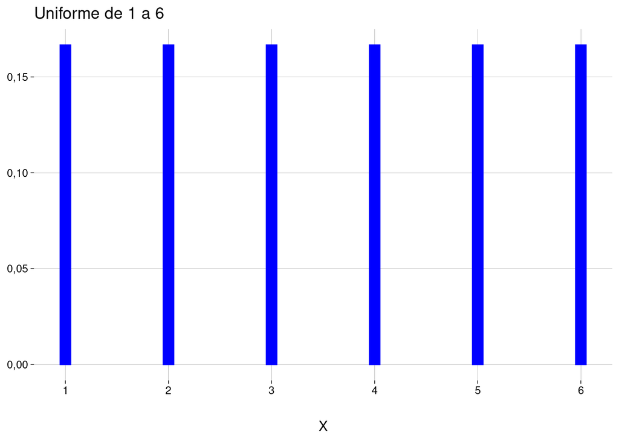

- Para gerar amostras, use `sample`, que, por *default*, trabalha com a distribuição uniforme discreta. Simulando dez lançamentos de um dado:

```r
sample(1:6, size = 10, replace = TRUE)
```

```
##  [1] 5 2 4 3 6 6 6 3 2 3
```

# 2 Bernoulli

## 2.1 Exemplo: uma moeda

- Dois resultados possíveis: coroa ou cara.
- Variável aleatória
  $$X = \begin{cases}
  0 &\text{se coroa} \\
  1 &\text{se cara}
  \end{cases}$$
- Parâmetro: $p$ é a probabilidade de sucesso (cara).
- Distribuição: $\text{Bernoulli}(X \mid p = 0{,}5)$ para uma moeda justa:
  $$\begin{align*}
  P(X = 0) &= 1 - 0{,}5 \\
  P(X = 1) &= 0{,}5
  \end{align*}$$
  também escrita como
  $$P(X = x) = 0{,}5^x \cdot (1 - 0{,}5)^{1 - x}$$
- Cada valor do parâmetro $p$ dá uma distribuição diferente.
- Gráfico com um valor específico de $p$:

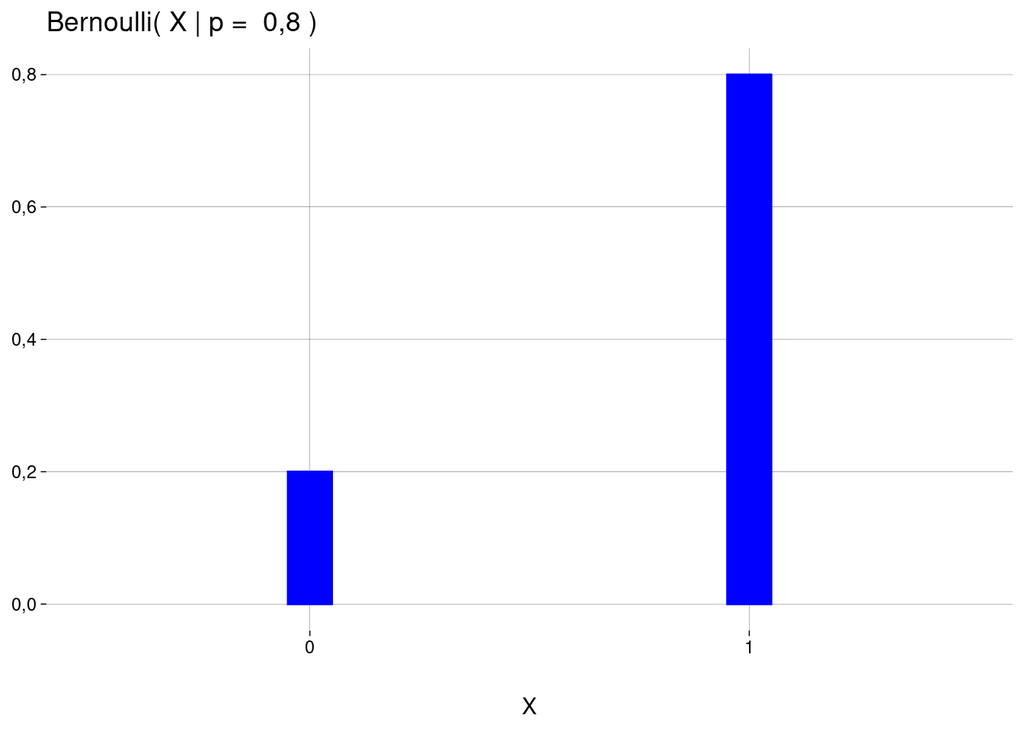

## 2.2 No geral

- $\text{Bernoulli}(X = x \mid p)$
- $x \in \{0, 1\}$
- $p \in [0, 1]$
- Valor esperado:
  $$\begin{align*}
  E(X) &= 0 \cdot (1 - p) \;+\: 1 \cdot p \\
  &= p
  \end{align*}$$
- Variância:
  $$\begin{align*}
  \sigma^2(X) &= (0 - p)^2 \cdot (1 - p) \;+\: (1 - p)^2 \cdot p \\
  &= p^2 - p^3 + p - 2p^2 + p^3 \\
  &= -p^2 + p \\
  &= p(1 - p)
  \end{align*}$$

## 2.3 Em R

A distribuição de Bernoulli é um caso especial ($n = 1$) da distribuição *binomial*, que nós vamos ver abaixo.

- Se você não quiser usar a distribuição binomial, pode usar um vetor de valores e um vetor de probabilidades (ambos de tamanho $2$), e usar `sample` com o argumento `prob`.
- Por exemplo, para simular $10$ lançamentos de uma moeda viciada:

```r
moeda <- 0:1
probs <- c(.2, .8)
sample(moeda, size = 10, prob = probs, replace = TRUE)
```

```
##  [1] 0 1 1 1 0 1 1 1 1 1
```

# 3 Geométrica

## 3.1 Exemplo: *spam*

- Cada e-mail tem probabilidade $0{,}1$ de não ser *spam*, e $0{,}9$ de ser *spam*.
- Considere que cada e-mail é *independente* de cada outro.
- Você abre sua *inbox* (sem filtro *antispam*) e começa a abrir as mensagens sequencialmente.
- A variável aleatória $X$ é o número de mensagens *spam* que você precisa abrir até chegar à primeira mensagem que não é *spam*.
- Suporte $\{0, 1, 2, 3, \ldots \}$
- Parâmetro: $p$ é a probabilidade de sucesso (não *spam*).
- Distribuição: $\text{Geom}(X \mid p = 0{,}1)$.
- Qual a probabilidade de que a primeira mensagem não-*spam* seja a décima?

- Gráfico:

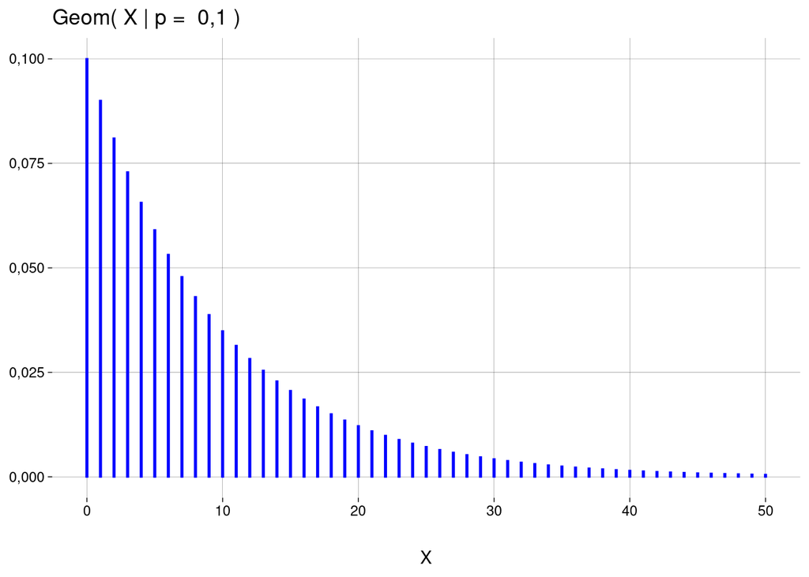

## 3.2 No geral

- $X$ conta a quantidade de *provas de Bernoulli* que têm resultado fracasso antes do primeiro sucesso.
- As provas de Bernoulli são independentes e têm probabilidade fixa de sucesso $p$.
- $\text{Geom}(X = x \mid p) = (1-p)^x \cdot p$
- $x \in \{0, 1, 2, \ldots\}$
- Valor esperado:

  Vamos chamar $1 - p$ de $q$. Então, $P(X = x) = q^x \cdot p$. Daí,

  $$\begin{align*}
  E(X) &= 0p + 1qp + 2q^2p + 3q^3p + \cdots \\
  &= 0(1-q) + 1q(1-q) + 2q^2(1-q) + 3q^3(1-q) + \cdots \\
  &= q - q^2 + 2q^2 - 2q^3 + 3q^3 - 3q^4 + \cdots \\
  &= q + q^2 + q^3 + \cdots \\
  &= \frac{q}{1-q} \\
  &= \frac{1-p}{p}
  \end{align*}$$

  No exemplo dos e-mails, $E(X) = \frac{1-p}{p} = \frac{0{,}9}{0{,}1} = 9$.
- Variância:

  $$\sigma^2(X) = \frac{1-p}{p^2}$$

## 3.3 Em R

### 3.3.1 Função de distribuição de probabilidade: $\text{Geom}(X = x \mid p)$

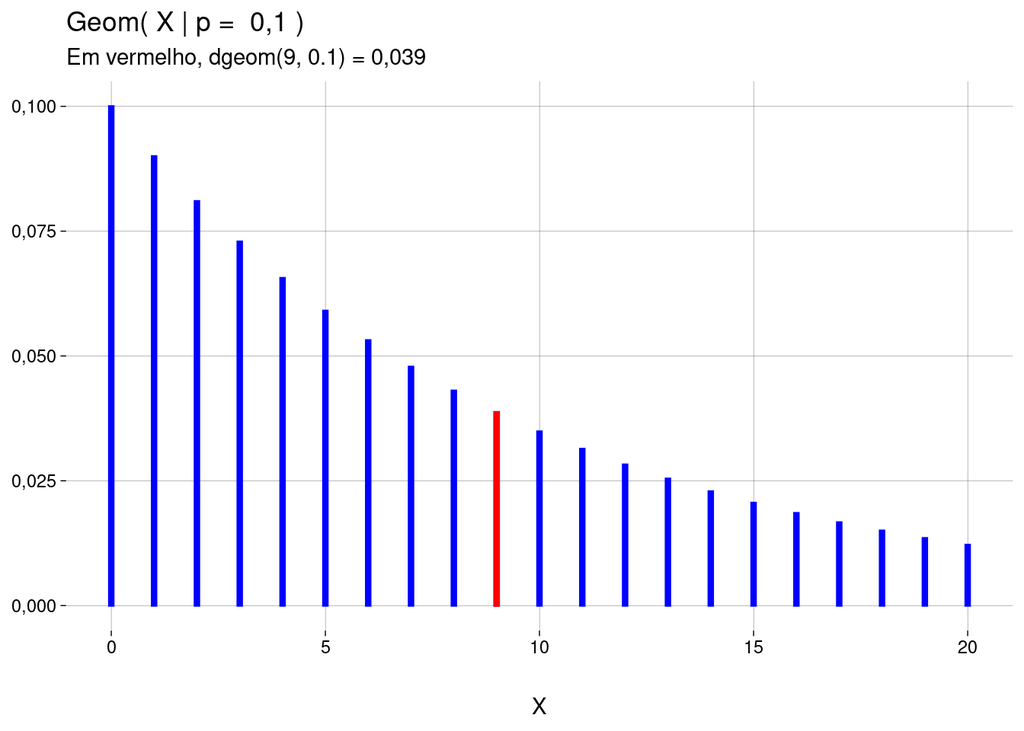

- `dgeom(x, prob)`
- Tanto `x` quanto `prob` podem ser vetores.
- No exemplo do *spam*, probabilidades de $X$ ser $0, 1, 2, \ldots, 10$:

```r
dgeom(x = 0:10, prob = .1)
```

```
##  [1] 0,10000000 0,09000000 0,08100000 0,07290000 0,06561000 0,05904900
##  [7] 0,05314410 0,04782969 0,04304672 0,03874205 0,03486784
```

- Se a probabilidade de *spam* for $0{,}1; 0{,}2; 0{,}3; \ldots; 0{,}9; 1{,}0$, qual a probabilidade de ter que abrir $10$ mensagens *spam* antes de chegar à primeira mensagem não-*spam*?

```r
dgeom(10, prob = seq(0.1, 1.0, 0.1))
```

```
##  [1] 0,03486784401 0,02147483648 0,00847425747 0,00241864704 0,00048828125
##  [6] 0,00006291456 0,00000413343 0,00000008192 0,00000000009 0,00000000000
```

- Mas cuidado: se os dois argumentos forem vetores, o resultado é um vetor com o comprimento do maior argumento, com os valores de `x` pareados um a um com os valores de `prob` (lembrando que R recicla o vetor mais curto):

```r
dgeom(c(10, 11, 12), c(0.1, 0.2))
```

```
## [1] 0,03486784 0,01717987 0,02824295
```

Os valores acima são, respectivamente, $P(X = 10 \mid p = 0{,}1)$, $P(X = 11 \mid p = 0{,}2)$ e $P(X = 12 \mid p = 0{,}1)$.

### 3.3.2 Função de distribuição acumulada: $\text{Geom}(X \leq q \mid p)$

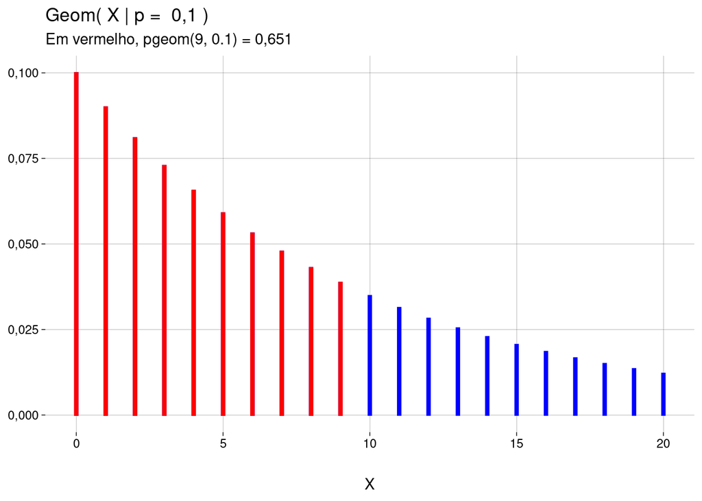

- `pgeom(q, prob, lower.tail = TRUE)`
- Se você passar `lower.tail = FALSE`, a probabilidade calculada é $P(X > q \mid \text{prob})$.

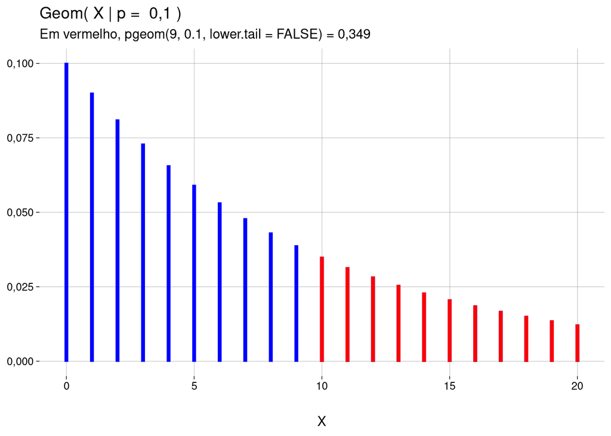

- Tanto `q` quanto `prob` podem ser vetores.
- No exemplo do *spam*, a probabilidade de precisar abrir *no máximo* $10$ mensagens *spam* para então abrir a primeira mensagem não-*spam* é

```r
  pgeom(q = 10, prob = .1)
```

```
## [1] 0,6861894
```

que, na verdade, é o mesmo que somar as probabilidades de $X = 0$, $X = 1$, etc., até $X = 10$:

```r
  sum(dgeom(0:10, .1))
```

```
## [1] 0,6861894
```

- Um exemplo mais realista: cada vez que você joga $6$ números na Mega-Sena, a probabilidade de você acertar a sena é de $1$ em $50.063.860$, segundo http://loterias.caixa.gov.br/wps/portal/loterias/landing/megasena.

  Qual a probabilidade de você acertar a sena em alguma das primeiras $1.000$ vezes que você jogar? $10.000$ vezes? $100.000$ vezes (o que equivale a $961{,}50$ anos, jogando $2$ vezes por semana)?

```r
  p <- 1/50063860
  pgeom(c(1e3, 1e4, 1e5), p)
```

```
## [1] 0,00001999426 0,00019974491 0,00199547524
```

Qual a probabilidade de você jogar duas vezes por semana, durante $100$ anos, sem acertar a sena? Considerando $52$ semanas por ano:

```r
  vezes <- 2 * 52 * 100
  vezes
```

```
## [1] 10400
```

```r
  pgeom(vezes, p, lower.tail = FALSE)
```

```
## [1] 0,9997923
```

O problema é que, com uma probabilidade de sucesso tão baixa, a distribuição geométrica começa em um valor baixo e decresce muito lentamente. O gráfico abaixo vai até $X = 1$ milhão. A área da faixa vermelha é a probabilidade de você acertar a sena jogando no máximo $10$ mil vezes. Esta probabilidade é $0{,}00$.

Isto equivale a dizer que a probabilidade de você precisar de mais de $10$ mil jogos para acertar a sena é de $1 - 0{,}00 = 1{,}00$, que é a área em azul no gráfico, *mais a área restante à direita, de $1$ milhão até o infinito*, que não aparece no gráfico!

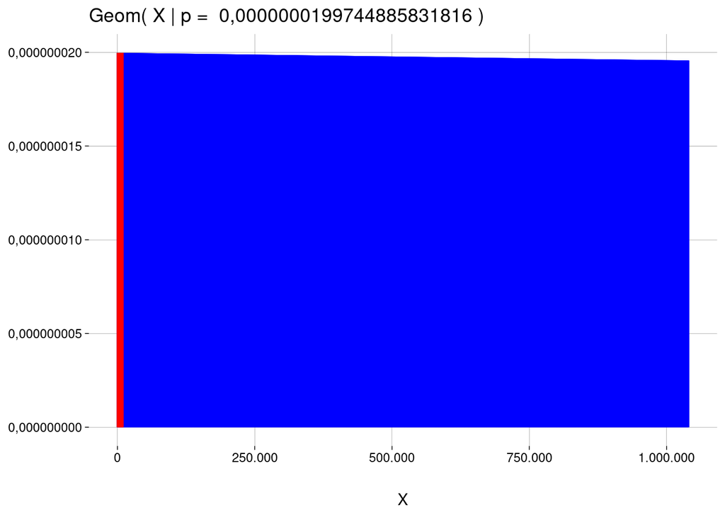

### 3.3.3 Função quantil: dado um valor de $\text{Geom}(X \leq x \mid p)$, então $x = ?$

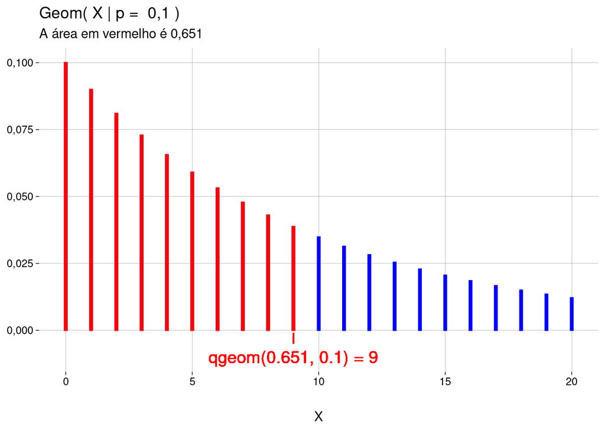

- `qgeom(p, prob, lower.tail = TRUE)`
- Se você passar `lower.tail = FALSE`, o quantil calculado é $q$ tal que $P(X > q \mid \text{prob}) = p$:

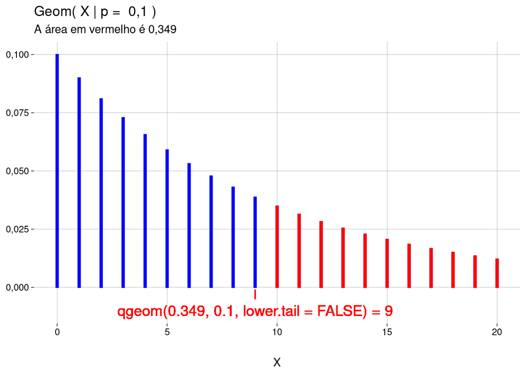

- Quantas vezes você precisa apostar $6$ números na Mega-Sena para ter $50$% de chance de acertar a sena alguma vez?

```r
p <- 1/50063860
qgeom(.5, p)
```

```
## [1] 34701623
```

- Isto equivale a $333.669$ anos, jogando duas vezes por semana, toda semana.

### 3.3.4 Geração de números aleatórios

- `rgeom(n, prob)` retorna um vetor de `n` valores sorteados de uma distribuição $\text{Geom}(X \mid \text{prob})$.
- Voltando ao exemplo do *spam*. Vamos simular muitos experimentos. Os resultados são os valores de $X$, i.e., as quantidades de mensagens *spam* que precisaram ser abertas antes de chegar à primeira mensagem não-spam:

```r
amostra <- rgeom(1000, .1)
head(amostra)
```

```
## [1]  2  4  3 28  0  6
```

- O valor esperado é $\frac{1-p}{p} = 9$. Vamos comparar com a média da amostra gerada:

```r
mean(amostra)
```

```
## [1] 9,308
```

- A variância é $\frac{1-p}{p^2} = 90{,}00$. Vamos comparar com a variância da amostra:

```r
var(amostra)
```

```
## [1] 95,51065
```

- Vamos simular $100$ mil pessoas jogando na Mega-Sena e ver se alguma acertou a sena antes de jogar mil vezes:

```r
p <- 1/50063860
resultados <- rgeom(1e5, p)
resultados[resultados <= 1e3]
```

```
## [1] 82
```

- Qual a média da nossa amostra? O valor esperado é $50.063.859$.

```r
mean(resultados)
```

```
## [1] 50431081
```

- E a mediana?

```r
median(resultados)
```

```
## [1] 34812294
```

- E o máximo?

```r
max(resultados)
```

```
## [1] 591957164
```

- E o mínimo?

```r
min(resultados)
```

```
## [1] 82
```

- Gráfico da nossa amostra:

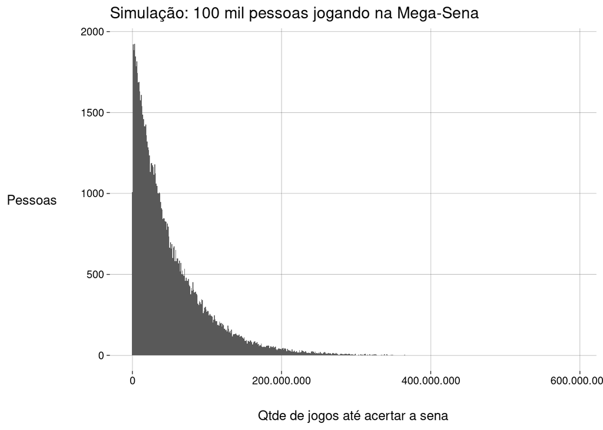

- Os sortudos:

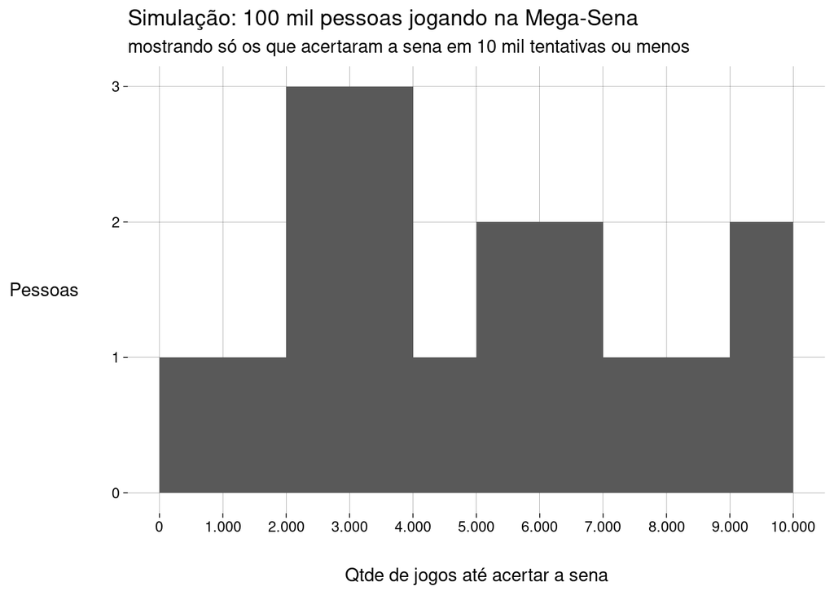

# 4 Binomial

## 4.1 Exemplo: *spam* novamente

- Vamos mudar para um mundo onde a probabilidade de uma mensagem qualquer *não* ser *spam* é $p = 0{,}3$ .
- Agora, vamos mudar o experimento: ao recebermos $n = 10$ mensagens, quantas não são *spam*?
- A variável aleatória $X$ é o número de sucessos (não *spam*) em $n = 10$ mensagens.
- Suporte $\{ 0, 1, 2, \ldots, 10 \}$
- Parâmetros:
  - $p$ é a probabilidade de sucesso (não *spam*).
  - $n$ é o número total de mensagens.
- Distribuição: $\text{Binom}(X \mid n = 10, p = 0{,}3)$.
- Qual a probabilidade de haver $4$ mensagens não *spam*? As mensagens são independentes. O resultado vai envolver:
  - A probabilidade de $4$ mensagens não serem *spam*: $(0{,}3)^4$.
  - A probabilidade de $6$ mensagens serem *spam*: $(1 - 0{,}3)^6$.
  - A quantidade de ordenações diferentes destas $10$ mensagens: ${10 \choose 4} = \frac{10!}{4!6!} = 210$.
  - O resultado é

$$\begin{align*}
\text{Binom}(X = 4 \mid n = 10,\; p = 0{,}3)
&= {10 \choose 4} \cdot (0{,}3)^4 \cdot (1 - 0{,}3)^6 \\
&= 0{,}20
\end{align*}$$

- Gráfico:

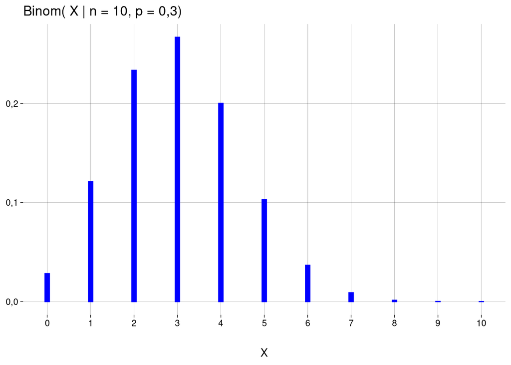

## 4.2 No geral

- $X$ conta a quantidade de sucessos em um número fixo $n$ de provas de Bernoulli.
- As provas de Bernoulli são independentes e têm probabilidade fixa de sucesso $p$.
- $\text{Binom}(X = x \mid n, p) = {n \choose x} \cdot p^x \cdot (1 - p)^{n - x}$
- $x \in \{ 0, 1, 2, \ldots, n\}$
- Valor esperado:
  - Na verdade, $X$ é a soma de $n$ variáveis aleatórias independentes $X_1, \ldots, X_n$, cada uma delas com distribuição de Bernoulli com probabilidade de sucesso $p$ (e valor esperado $p$):

$$\begin{align*}
E(X) &= E(X_1 + \cdots + X_n) \\
&= E(X_1) + \cdots + E(X_n) \\
&= p + \cdots + p \\
&= np
\end{align*}$$

- Variância:
  - Como as variáveis $X_1, \ldots, X_n$ são independentes, a variância da soma é a soma das variâncias:

$$\begin{align*}
\sigma^2(X) &= \sigma^2(X_1 + \cdots + X_n) \\
&= \sigma^2(X_1) + \cdots + \sigma^2(X_n) \\
&= p(1-p) + \cdots + p(1-p) \\
&= np(1-p)
\end{align*}$$

## 4.3 Em R

### 4.3.1 Função de distribuição de probabilidade: $\text{Binom}(X = x \mid n, p)$

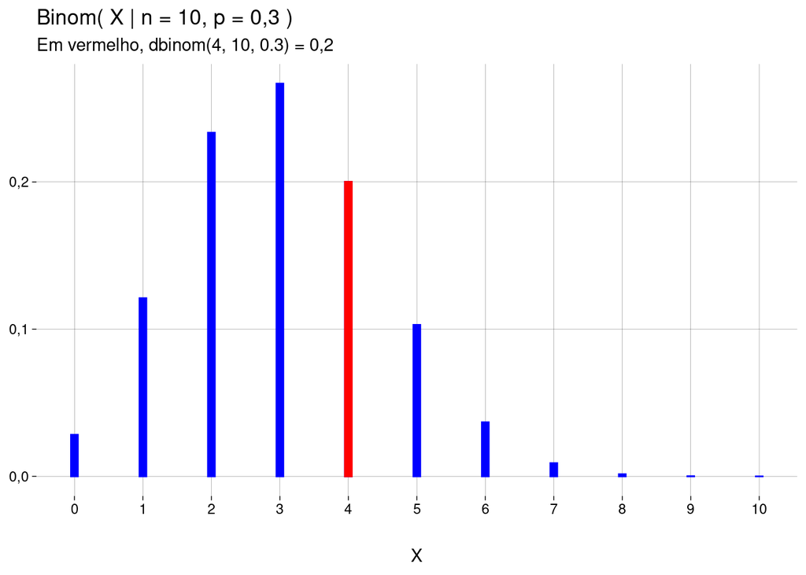

- `dbinom(x, size, prob)`
- Voltando à Mega-Sena: para uma única pessoa, jogar é uma prova de Bernoulli, com probabilidade de sucesso de $1/50.063.860 = 0{,}00$. Se você jogar $6$ números $10$ mil vezes — duas vezes por semana, durante quase $100$ anos — sua probabilidade de ganhar exatamente duas vezes é

```r
p <- 1/50063860
vezes <- 1e4
dbinom(2, vezes, p)
```

```
## [1] 0,00000001994303
```

- O gráfico desta distribuição é

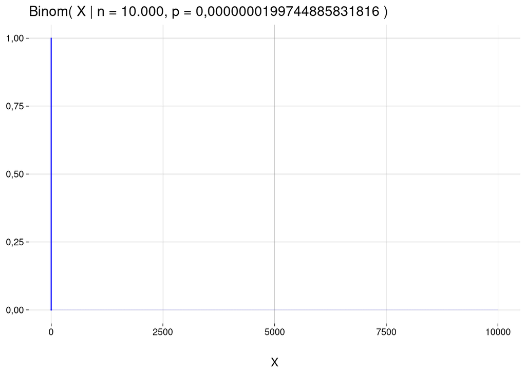

- A probabilidade de jogar $10$ mil vezes e obter zero sucessos é

```r
dbinom(0, n, p_sucesso)
```

```
## [1] 0,9998003
```

### 4.3.2 Função de distribuição acumulada: $\text{Binom}(X \leq q \mid n, p)$

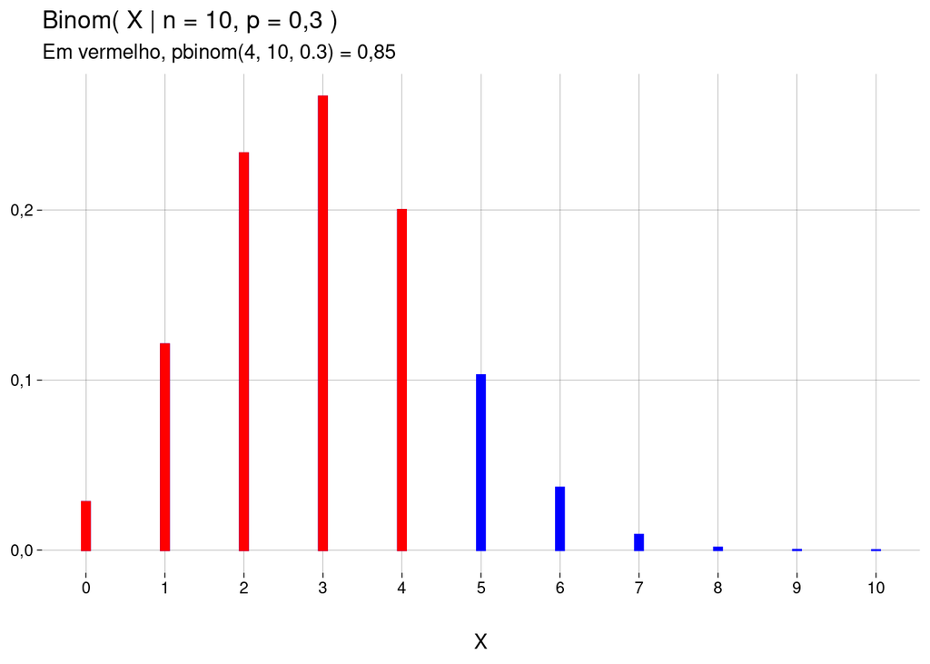

- `pbinom(q, size, prob, lower.tail = TRUE)`
- Se você passar `lower.tail = FALSE`, a probabilidade calculada é $P(X>q \mid \text{size}, \text{prob})$.

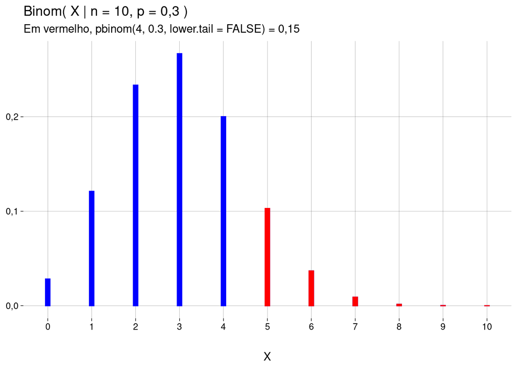

### 4.3.3 Função quantil: dado um valor de $\text{Binom}(X \leq x \mid n, p)$, então $x = ?$

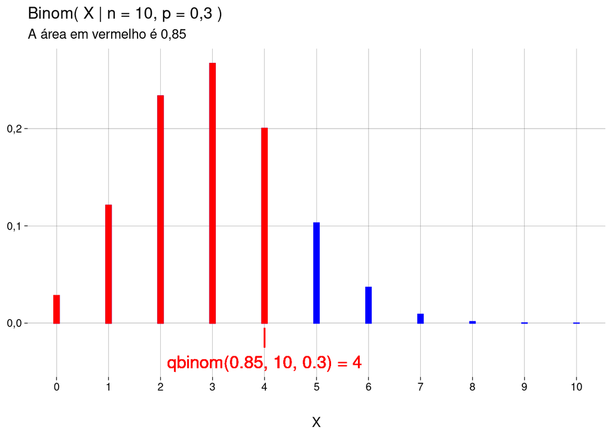

- `qbinom(p, size, prob)`
- Se você passar `lower.tail = FALSE`, o quantil calculado é $q$ tal que $P(X > q \mid \text{size}, \text{prob}) = p$:

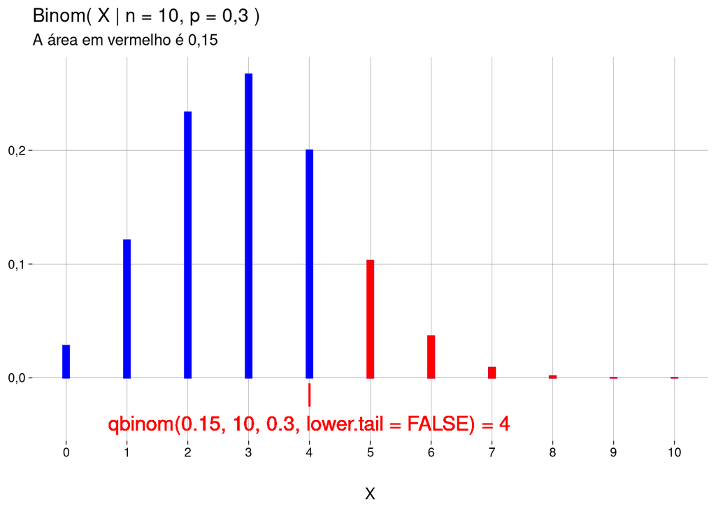

### 4.3.4 Geração de números aleatórios

- `rbinom(n, size, prob)` retorna um vetor de `n` valores sorteados de uma distribuição $\text{Binom}(X \mid \text{size}, \text{prob})$.
- Vamos simular $100$ vezes o experimento de abrir $10$ mensagens e contar quantas delas não são *spam*:

```r
amostra <- rbinom(100, 10, .3)
amostra
```

```
##   [1] 3 4 1 2 1 2 4 1 2 3 3 3 3 5 4 4 4 4 2 2 0 4 2 4 6 4 5 4 0 3 5 1 1 2 0 6 5
##  [38] 1 2 3 4 5 3 3 2 1 3 1 4 3 3 3 3 3 2 4 4 3 5 5 2 1 3 1 1 1 4 3 4 5 3 3 7 6
##  [75] 2 3 1 4 2 3 4 1 4 1 2 1 4 5 3 2 4 2 0 3 3 5 0 4 5 2
```

- Média:

```r
mean(amostra)
```

```
## [1] 2,93
```

- Finalmente, vamos simular $100$ mil pessoas, cada uma jogando $10$ mil jogos da Mega-Sena e ver quantas ganharam pelo menos uma vez:

```r
n <- 1e5
p <- 1/50063860
size <- 1e4

resultados <- rbinom(n, size, p)
head(resultados, 1000)
```

```
##    [1] 0 0 0 0 0 0 0 0 0 0 0 0 0 0 0 0 0 0 0 0 0 0 0 0 0 0 0 0 0 0 0 0 0 0 0 0 0
##   [38] 0 0 0 0 0 0 0 0 0 0 0 0 0 0 0 0 0 0 0 0 0 0 0 0 0 0 0 0 0 0 0 0 0 0 0 0 0
##   [75] 0 0 0 0 0 0 0 0 0 0 0 0 0 0 0 0 0 0 0 0 0 0 0 0 0 0 0 0 0 0 0 0 0 0 0 0 0
##  [112] 0 0 0 0 0 0 0 0 0 0 0 0 0 0 0 0 0 0 0 0 0 0 0 0 0 0 0 0 0 0 0 0 0 0 0 0 0
##  [149] 0 0 0 0 0 0 0 0 0 0 0 0 0 0 0 0 0 0 0 0 0 0 0 0 0 0 0 0 0 0 0 0 0 0 0 0 0
##  [186] 0 0 0 0 0 0 0 0 0 0 0 0 0 0 0 0 0 0 0 0 0 0 0 0 0 0 0 0 0 0 0 0 0 0 0 0 0
##  [223] 0 0 0 0 0 0 0 0 0 0 0 0 0 0 0 0 0 0 0 0 0 0 0 0 0 0 0 0 0 0 0 0 0 0 0 0 0
##  [260] 0 0 0 0 0 0 0 0 0 0 0 0 0 0 0 0 0 0 0 0 0 0 0 0 0 0 0 0 0 0 0 0 0 0 0 0 0
##  [297] 0 0 0 0 0 0 0 0 0 0 0 0 0 0 0 0 0 0 0 0 0 0 0 0 0 0 0 0 0 0 0 0 0 0 0 0 0
##  [334] 0 0 0 0 0 0 0 0 0 0 0 0 0 0 0 0 0 0 0 0 0 0 0 0 0 0 0 0 0 0 0 0 0 0 0 0 0
##  [371] 0 0 0 0 0 0 0 0 0 0 0 0 0 0 0 0 0 0 0 0 0 0 0 0 0 0 0 0 0 0 0 0 0 0 0 0 0
##  [408] 0 0 0 0 0 0 0 0 0 0 0 0 0 0 0 0 0 0 0 0 0 0 0 0 0 0 0 0 0 0 0 0 0 0 0 0 0
##  [445] 0 0 0 0 0 0 0 0 0 0 0 0 0 0 0 0 0 0 0 0 0 0 0 0 0 0 0 0 0 0 0 0 0 0 0 0 0
##  [482] 0 0 0 0 0 0 0 0 0 0 0 0 0 0 0 0 0 0 0 0 0 0 0 0 0 0 0 0 0 0 0 0 0 0 0 0 0
##  [519] 0 0 0 0 0 0 0 0 0 0 0 0 0 0 0 0 0 0 0 0 0 0 0 0 0 0 0 0 0 0 0 0 0 0 0 0 0
##  [556] 0 0 0 0 0 0 0 0 0 0 0 0 0 0 0 0 0 0 0 0 0 0 0 0 0 0 0 0 0 0 0 0 0 0 0 0 0
##  [593] 0 0 0 0 0 0 0 0 0 0 0 0 0 0 0 0 0 0 0 0 0 0 0 0 0 0 0 0 0 0 0 0 0 0 0 0 0
##  [630] 0 0 0 0 0 0 0 0 0 0 0 0 0 0 0 0 0 0 0 0 0 0 0 0 0 0 0 0 0 0 0 0 0 0 0 0 0
##  [667] 0 0 0 0 0 0 0 0 0 0 0 0 0 0 0 0 0 0 0 0 0 0 0 0 0 0 0 0 0 0 0 0 0 0 0 0 0
##  [704] 0 0 0 0 0 0 0 0 0 0 0 0 0 0 0 0 0 0 0 0 0 0 0 0 0 0 0 0 0 0 0 0 0 0 0 0 0
##  [741] 0 0 0 0 0 0 0 0 0 0 0 0 0 0 0 0 0 0 0 0 0 0 0 0 0 0 0 0 0 0 0 0 0 0 0 0 0
##  [778] 0 0 0 0 0 0 0 0 0 0 0 0 0 0 0 0 0 0 0 0 0 0 0 0 0 0 0 0 0 0 0 0 0 0 0 0 0
##  [815] 0 0 0 0 0 0 0 0 0 0 0 0 0 0 0 0 0 0 0 0 0 0 0 0 0 0 0 0 0 0 0 0 0 0 0 0 0
##  [852] 0 0 0 0 0 0 0 0 0 0 0 0 0 0 0 0 0 0 0 0 0 0 0 0 0 0 0 0 0 0 0 0 0 0 0 0 0
##  [889] 0 0 0 0 0 0 0 0 0 0 0 0 0 0 0 0 0 0 0 0 0 0 0 0 0 0 0 0 0 0 0 0 0 0 0 0 0
##  [926] 0 0 0 0 0 0 0 0 0 0 0 0 0 0 0 0 0 0 0 0 0 0 0 0 0 0 0 0 0 0 0 0 0 0 0 0 0
##  [963] 0 0 0 0 0 0 0 0 0 0 0 0 0 0 0 0 0 0 0 0 0 0 0 0 0 0 0 0 0 0 0 0 0 0 0 0 0
## [1000] 0
```

```r
ganhadores <- resultados[resultados > 0]
ganhadores
```

```
##  [1] 1 1 1 1 1 1 1 1 1 1 1 1 1 1 1 1 1 1 1 1
```

```r
length(ganhadores)
```

```
## [1] 20
```

# 5 Poisson

## 5.1 Exemplo

- Em um caixa de um pequeno mercado, o número de clientes que chegam por minuto é, em média, $4$.
- Vamos representar este número pela variável aleatória $X$, com suporte $\{ 0, 1, 2, 3, \ldots \}$.
- As chegadas dos clientes são independentes umas das outras.
- Se você dividir o tempo em intervalos menores do que um minuto, a média se mantém: $2$ clientes a cada $30$ segundos, $1$ cliente a cada $15$ segundos etc.
- Clientes diferentes não chegam ao caixa no mesmo instante.
- Com estas condições, e chamando o número médio de $\lambda = 4$, a probabilidade de que $10$ clientes cheguem ao caixa em um período de um minuto é dada por

$$\begin{align*}
P(X = 10) &= \text{Poisson}(X = 10 \mid \lambda = 4) \\
&= \frac{\lambda^{10}}{10!}e^{-\lambda} \\
&= \frac{4^{10}}{10!}e^{-4} \\
&= 0{,}01
\end{align*}$$

- A probabilidade de que o caixa fique vazio durante um minuto inteiro é

$$\begin{align*}
P(X = 10) &= \text{Poisson}(X = 0 \mid \lambda = 4) \\
&= \frac{\lambda^{0}}{0!}e^{-\lambda} \\
&= \frac{4^{0}}{0!}e^{-4} \\
&= 0{,}02
\end{align*}$$

- O gráfico (até $X = 20$) é

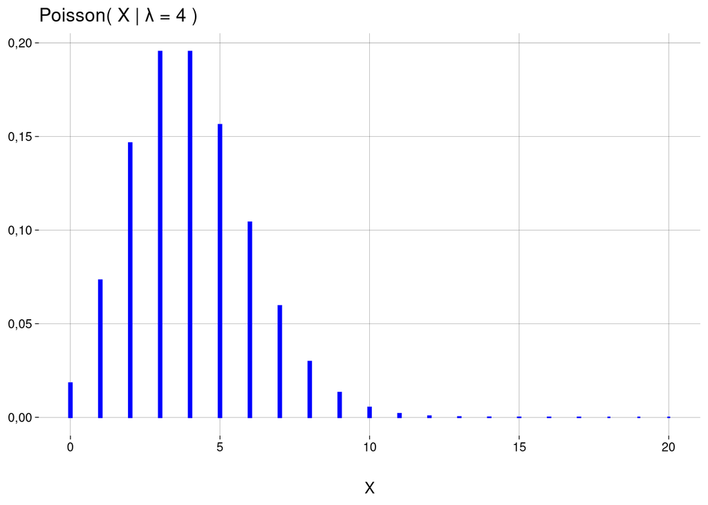

## 5.2 No geral

- A distribuição de Poisson é um bom modelo para situações em que a variável aleatória $X$ conta o número de ocorrências de algum fenômeno em um intervalo de tempo fixo (ou em uma área ou volume de espaço):
  - Carros passando em um cruzamento em uma hora,
  - Chamadas telefônicas chegando por minuto a uma central,
  - Partículas alfa emitidas por minuto por $1$Kg de um material radioativo,
  - Casos de uma doença detectados em cada Km$^2$ de uma cidade,
  - Erros de impressão por página em livros produzidos por uma editora.
- Teoricamente, $P(X=x)$ é maior que zero para qualquer $x$ natural; no mundo real, existem valores máximos que estas variáveis aleatórias podem assumir. Ainda assim, esta distribuição é uma boa aproximação. Por exemplo, a probabilidade de $40$ ou mais clientes chegarem ao nosso caixa de mercado em um minuto é de $0{,}00$.
- O valor esperado $E(X)$ e a variância $\sigma^2(X)$ são iguais a $\lambda$.

## 5.3 Em R

### 5.3.1 Exercício

Seguindo o estilo das explicações sobre a distribuição geométrica e a distribuição binomial:

1. Gere gráficos com exemplos do uso de `dpois`.
2. Gere gráficos com exemplos do uso de `ppois`.
3. Gere gráficos com exemplos do uso de `qpois`.
4. Faça uma simulação usando `rpois`. Detalhe o exemplo do nosso pequeno mercado, que atende $4$ clientes por minuto:
   1. Gere uma amostra de números correspondendo a $1$ hora de funcionamento do caixa.
   2. Escreva uma função em R para processar esta amostra e retornar um vetor com a quantidade de clientes na fila ao final de cada minuto (de $1$ a $60$). Lembre-se de que o caixa processa $4$ clientes por minuto.
   3. Agora gere uma amostra de números correspondendo a $1$ hora de funcionamento do caixa, com uma média de $5$ clientes chegando por minuto.
   4. Use a função que você escreveu para processar esta amostra e retornar um vetor com a quantidade de clientes na fila a cada minuto (de $1$ a $60$), *supondo que o caixa ainda processa só $4$ clientes por minuto*.

## 5.4 Aproximação da Binomial pela Poisson

- Um fabricante de carros descobre que $1$ em cada $2.500$ carros que ele produz tem um defeito.
- Qual a probabilidade de achar $4$ carros com defeito em uma amostra de $6.000$ carros?
- Vamos usar $\text{Binom}\left(X \;\middle\vert\;n = 6.000, p = \frac{1}{2.500}\right)$:

```r
prob <- 1/2500
size <- 6000
x <- 4
dbinom(x, size, prob)
```

```
## [1] 0,1254235
```

- Mas, e se modelarmos o problema com Poisson em vez da Binomial?
- Uma das condições para usar Poisson é que a média seja constante. Para $6.000$ carros, a média de defeitos é $\frac{6.000}{2.500} = 2{,}40$.
- Vamos usar, então, $\text{Poisson}\left(X \;\middle\vert\; \lambda = 2{,}40 \right)$:

```r
lambda <- 6000/2500
x <- 4
dpois(x, lambda)
```

```
## [1] 0,1254085
```

- Gráfico:

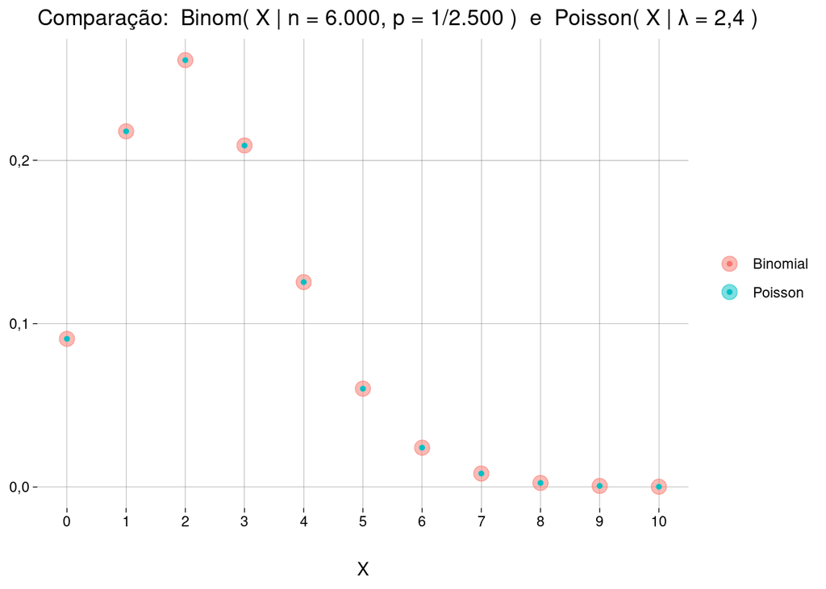

- Para valores grandes de $n~(6.000)$ e pequenos de $p~(1/2.500)$, a Binomial pode ser aproximada pela Poisson — desde que você calcule a média $\lambda$, como fizemos.
- A vantagem é que, diferente da Binomial, a Poisson não exige o cálculo do valor de $n \choose x$, que pode ser inviável mesmo com um computador.

#### Por quê?

O exemplo da quantidade de emissões de partículas alfa por minuto por uma massa fixa de material radioativo mostra uma relação fundamental entre as duas distribuições:

- Do ponto de vista de Poisson, sabemos a média de emissões por minuto do material, sem levar em consideração o comportamento de cada átomo.
- Do ponto de vista da Binomial, o material é composto por um número enorme de átomos ($n$ é grande!), cada átomo com uma probabilidade fixa e muito baixa ($p$ pequeno!) de emitir uma partícula alfa no período de um minuto.

# 6 Funções para distribuições em R

A esta altura, você já entendeu como funcionam as funções do R para distribuições discretas de probabilidade. Para uma distribuição de nome `DISTRIB`, as funções são as seguintes (`...` representam os parâmetros da distribuição):

# 7 Jardim zoológico de distribuições

Para sua diversão: https://ben18785.shinyapps.io/distribution-zoo/